# Homework 4: Diffusion of Tetracycline

梁凯毅 3170104603

We continue examining the diffusion of tetracycline among doctors in Illinois in the early 1950s, building on our work in lab 6. You will need the data sets `ckm_nodes.csv` and `ckm_network.dat` from the labs.

1. Clean the data to eliminate doctors for whom we have no adoption-date information, as in the labs. Only use this cleaned data in the rest of the assignment.

```r
ckm_nodes<-read_csv("../data/ckm_nodes.csv")
vec1<-which(ckm_nodes$adoption_date!="NA")
ckm_nodes<-ckm_nodes[vec1,]
ckm_network<-read.table("../data/ckm_network.dat")
ckm_network<-ckm_network[vec1,vec1]
```

2. Create a new data frame which records, for every doctor, for every month, whether that doctor began prescribing tetracycline that month, whether they had adopted tetracycline before that month, the number of their contacts who began prescribing strictly *before* that month, and the number of their contacts who began prescribing in that month or earlier. Explain why the dataframe should have 6 columns, and 2125 rows. Try not to use any loops.

**解**：

```r
doctor<-(rep(1:125,each=17))
month<-(rep(1:17,125))
newckm<-data.frame(doctor,month)
newckm<-newckm %>% mutate(begin =
                              (ckm_nodes$adoption_date[doctor]==month))
newckm<-newckm %>% mutate(before =
                              (ckm_nodes$adoption_date[doctor]<month))
newckm<-newckm %>% group_by(doctor,month) %>%
    mutate(constrbefore=
                  sum((ckm_network[,doctor]==1)&
                          (ckm_nodes$adoption_date<month))) %>%
    ungroup()
newckm<-newckm %>% group_by(doctor,month) %>%
    mutate(conbefore=
                  sum((ckm_network[,doctor]==1)&
                          (ckm_nodes$adoption_date<=month))) %>%
    ungroup()
newckm
```

| doctor | month | begin | before | constrbefore | conbefore |
| --- | --- | --- | --- | --- | --- |
| 1 | 1 | TRUE | FALSE | 0 | 1 |
| 1 | 2 | FALSE | TRUE | 1 | 1 |
| 1 | 3 | FALSE | TRUE | 1 | 2 |
| 1 | 4 | FALSE | TRUE | 2 | 3 |
| 1 | 5 | FALSE | TRUE | 3 | 3 |
| 1 | 6 | FALSE | TRUE | 3 | 3 |
| 1 | 7 | FALSE | TRUE | 3 | 3 |
| 1 | 8 | FALSE | TRUE | 3 | 3 |
| 1 | 9 | FALSE | TRUE | 3 | 3 |
| 1 | 10 | FALSE | TRUE | 3 | 3 |

[output cut: 2115 more lines]

```r
max(newckm$constrbefore)
```

```
## [1] 18
```

3. Let
   $$p_k = \Pr(\text{A doctor starts prescribing tetracycline this month} \mid \\
   \text{Number of doctor's contacts prescribing before this month}=k)$$
   and
   $$q_k = \Pr(\text{A doctor starts prescribing tetracycline this month} \mid \\ \text{Number of doctor's contacts prescribing this month}=k)$$
   We suppose that $p_k$ and $q_k$ are the same for all months.
1. Explain why there should be no more than $21$ values of $k$ for which we can estimate $p_k$ and $q_k$ directly from the data.

**解**：

```r
max(colSums(ckm_network))
```

```
## [1] 20
```

这说明每个doctor最多和20个人有contact，所以k最多取值为$0,1,\cdots,20$共21个值。

2. Create a vector of estimated $p_k$ probabilities, using the data frame from (2). Plot the probabilities against the number of prior-adoptee contacts $k$.

**解**：

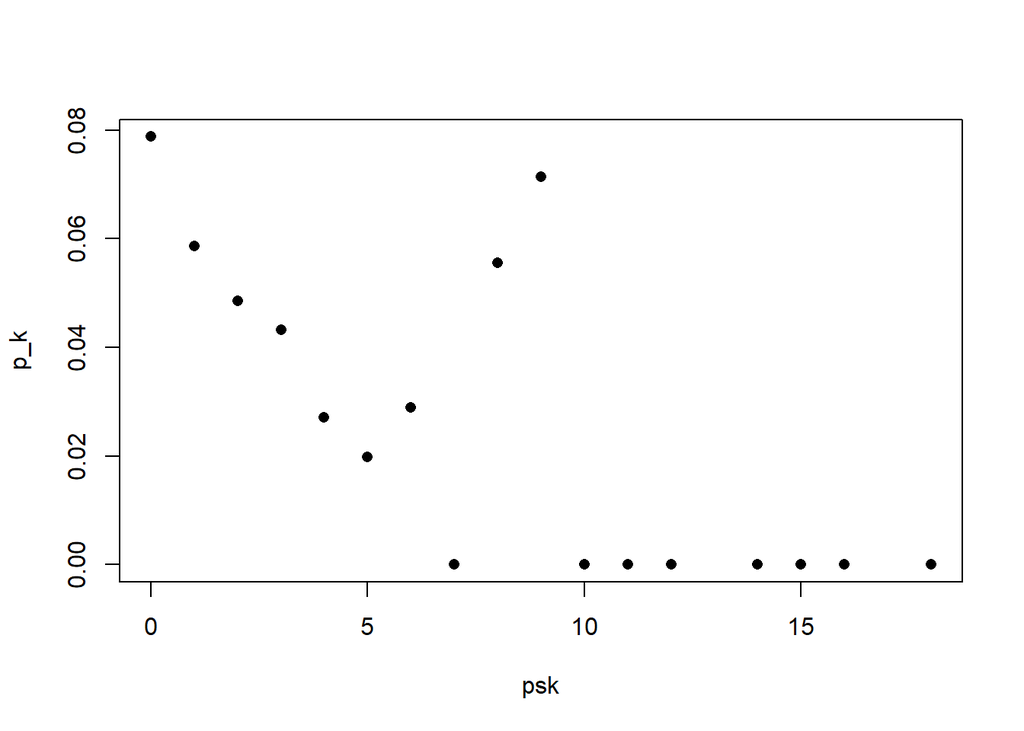

```r
p_k<-c()
psk<-c()
for(k in 0:20){
    if(dim(newckm %>% dplyr::filter(constrbefore==k))[1]!=0){
        tmp<-sum((newckm %>% dplyr::filter(constrbefore==k))$begin)/
            dim(newckm %>% dplyr::filter(constrbefore==k))[1]
        p_k<-c(p_k,tmp)
        psk<-c(psk,k)
    }
}
plot(p_k~psk,pch=16)
```

c. Create a vector of estimated $q_k$ probabilities, using the data frame from (2). Plot the probabilities against the number of prior-or-contemporary-adoptee contacts $k$.

**解**：

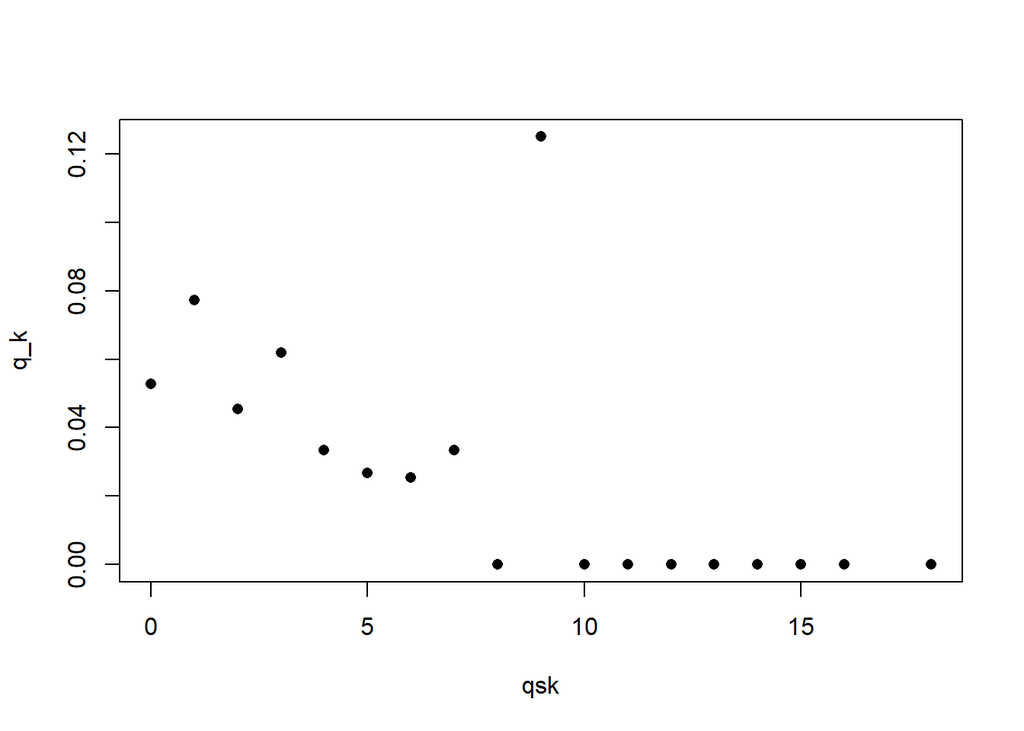

```r
q_k<-c()
qsk<-c()
for(k in 0:20){
    if(dim(newckm %>% dplyr::filter(conbefore==k))[1]!=0){
        tmp<-sum((newckm %>% dplyr::filter(conbefore==k))$begin)/
            dim(newckm %>% dplyr::filter(conbefore==k))[1]
        q_k<-c(q_k,tmp)
        qsk<-c(qsk,k)
    }
}
plot(q_k~qsk,pch=16)
```

4. Because it only conditions on information from the previous month, $p_k$ is a little easier to interpret than $q_k$. It is the probability per month that a doctor adopts tetracycline, if they have exactly $k$ contacts who had already adopted tetracycline.
1. Suppose $p_k = a + bk$. This would mean that each friend who adopts the new drug increases the probability of adoption by an equal amount. Estimate this model by least squares, using the values you constructed in (3b). Report the parameter estimates.

**解**：

```r
p_k_coef<-coefficients(lm(p_k~psk))
p_k_coef
```

```
##  (Intercept)          psk
##  0.056932428 -0.003799739
```

2. Suppose $p_k = e^{a+bk}/(1+e^{a+bk})$. Explain, in words, what this model would imply about the impact of adding one more adoptee friend on a given doctor’s probability of adoption. (You can suppose that $b > 0$, if that makes it easier.) Estimate the model by least squares, using the values you constructed in (3b).

**解**：

```r
minpk<-function(coe){
    p_k1<-exp(coe[1]+coe[2]*psk)/(1+exp(coe[1]+coe[2]*psk))
    return(sum((p_k1-p_k)^2)/length(psk))
}
```

```r
p_k_fit<-nlm(minpk,c(1,0))
print(paste("minimum:",p_k_fit$minimum))
```

```
## [1] "minimum: 0.000337758291140194"
```

```r
print(paste("a=",p_k_fit$estimate[1],",b=",p_k_fit$estimate[2]))
```

```
## [1] "a= -2.56507955559988 ,b= -0.170509178827445"
```

3. Plot the values from (3b) along with the estimated curves from (4a) and (4b). (You should have one plot, with $k$ on the horizontal axis, and probabilities on the vertical axis .) Which model do you prefer, and why?

**解**：

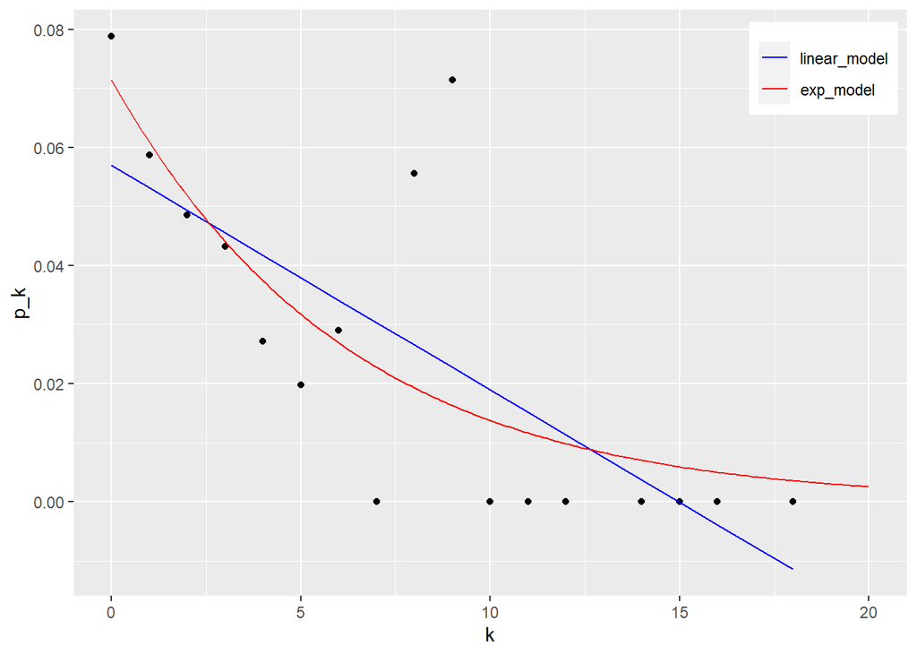

```r
tx<-seq(0,20,0.1)
ggplot()+
    geom_point(aes(x=psk,y=p_k),color="black")+
    geom_line(aes(x=psk,y=p_k_coef[1]+
                    p_k_coef[2]*psk,color="blue"))+
    geom_line(aes(x=tx,y=exp(p_k_fit$estimate[1]+
                                 p_k_fit$estimate[2]*tx)/
                (1+exp(p_k_fit$estimate[1]+
                         p_k_fit$estimate[2]*tx)),color="red"))+
  labs(x="k",y="p_k")+
  scale_color_manual(name = "group",
                     values = c( "blue" ='blue','red'='red'),
                     breaks = c('blue','red' ),
                     labels = c('linear_model','exp_model'))+
  theme(legend.title=element_blank(),
           legend.position = c(0.9, 0.9))
```

*For quibblers, pedants, and idle hands itching for work to do*: The $p_k$ values from problem 3 aren’t all equally precise, because they come from different numbers of observations. Also, if each doctor with $k$ adoptee contacts is independently deciding whether or not to adopt with probability $p_k$, then the variance in the number of adoptees will depend on $p_k$. Say that the actual proportion who decide to adopt is $\hat{p}_k$. A little probability (exercise!) shows that in this situation, $\mathbb{E}[\hat{p}_k] = p_k$, but that $\mathrm{Var}[\hat{p}_k] = p_k(1-p_k)/n_k$, where $n_k$ is the number of doctors in that situation. (We estimate probabilities more precisely when they’re really extreme [close to 0 or 1], and/or we have lots of observations.) We can estimate that variance as $\hat{V}_k = \hat{p}_k(1-\hat{p}_k)/n_k$. Find the $\hat{V}_k$, and then re-do the estimation in (4a) and (4b) where the squared error for $p_k$ is divided by $\hat{V}_k$. How much do the parameter estimates change? How much do the plotted curves in (4c) change?

**解**：

按照我对题目的理解（看不懂$\hat{V}_k$的含义），$\hat{p}_k$对每个$k$都是一个随机变量，均值为$p_k$，方差为$\frac{p_k(1-p_k)}{n_k}$，这是一个确定的值，所以构造squar minimum的方程时，发现为
$$\sum_kE[(\hat{p}_k-f(k)^2)]=\sum_kE[(\hat{p}_k-p_k)^2]+2E[(\hat{p}_k-p_k)(p_k-f(k))]+E[(p_k-f(k))^2]=\sum_k\frac{p_k(1-p_k)}{n_k}+(p_k-f(k))^2$$
这与之前的情形只相差了一个常数，所以在最优化方面与之前的结果应当完全一致。